# Exercising Right: Using sensors to ensure proper form

## synopsis

Many people measure the amount they exercise (miles run, weights lifted, etc.). Few measure the quality of their exercise, their “form”. Using data from sensors placed on the belts, forearms, arms, and dumbells of six participants, I used four algorithms to classify barbell lifts. Classifications range from correct form (class A) to four incorrect forms including throwing the elbows (class B), throwing the hips (class E), etc..

I walk thru model construction below including use of cross validation, estimates of out-of-sample error rates and the rationale for decisions made along the way.

## the model

### getting data

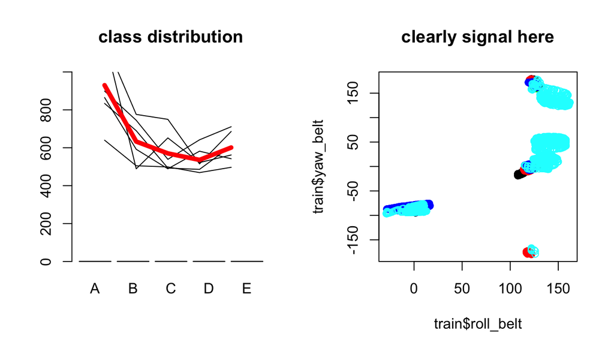

### cleaning data

I generated four train/test datasets. While I deleted timestamp and window columns for all datasets (to the extent exercisers are following a script, these columns provide information that wouldn’t be available otherwise), each dataset was developed according to its own methodology. Highlights include: 1. $ I replaced NA’s by the means for their respective columns. Given most algorithms use column variance for predictions, this approach elimnates NAs while not changing column variance. 2. $ I deleted rows with near zero varaiance (nzv()) then set NAs in remaining columns to the respective column mean. 3. $ I deleted columns with greater than 97% NA. 4. $ I converted factor to numeric using $levels(train.rev[,i]))[train.rev[,i]]$, then set any remaining NAs to the respective column means.

The effect of these changes and others not covered is illusrated in the kurtosis graphic below. From left to right I show how how the data was imported, what the data looke like using for train.base and what the data looked like for train.rev.

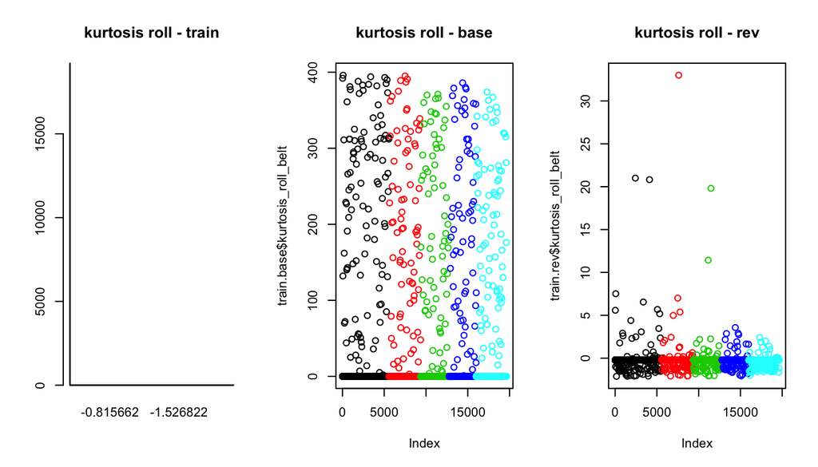

### pca pre-processing

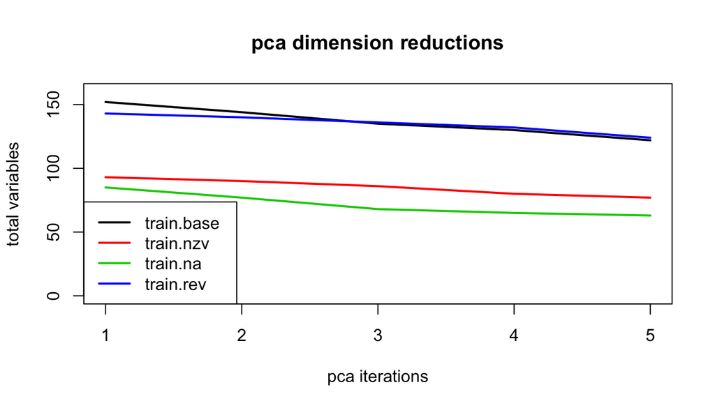

```r
dset=list(ds=list("train.base","train.nzv","train.na","train.rev"),
          trnx=list(train.base,train.nzv,train.na,train.rev),
          trny=train$classe)

par(mfrow=c(1,1))
plot(1:5,type="n",main="pca dimension reductions",ylim=c(0,160),xlab="pca iterations",ylab="total variables")

for(k in 1:length(dset$trnx)){
     target=dset$trnx[[k]][,c(2:(dim(dset$trnx[[k]])[2]-1))]
     gph.line=NULL
     cat("********** new file: ",dset$ds[[k]],"\n")
     for(i in 1:5){ # was 7
          cat("1. start: dim(target)",dim(target),"\n")
          gph.line[i]=dim(target)[2]
          cor.decs=matrix(NA,dim(target)[2],2)
          M=abs(cor(target)) # find predictors w/ high correlation
          diag(M)=0 # set cor for vars w/ themselves to 0

          for(j in 1:dim(target)[2]){
               cor.decs[j,1]=j
               cor.decs[j,2]=length(which(M[,j]>max(0.5,(1-0.1*i)),arr.ind=T))
          }
          clean=target[,c(which(M[,which.max(cor.decs[,2])]>max(0.5,(1-0.1*i)),arr.ind=T),
                          which.max(cor.decs[,2]))]

          cat("2. consolidating: ",cor.decs[which.max(cor.decs[,2]),][2]+1,"\n")
          comps=prcomp(clean);print(summary(comps))

          target=target[,-c(which(M[,which.max(cor.decs[,2])]>max(0.5,(1-0.1*i)),arr.ind=T),
                            which.max(cor.decs[,2]))]

          tmp=as.matrix(summary(comps)$importance);pc.cut=which(tmp[3,]>0.95)[1]
          comps=comps$x[,1:pc.cut];comps=as.data.frame(comps)
          for(z in 1:pc.cut){
               colnames(comps)[z]=c(sprintf("%s_%s_%s_%s","iter",i,"pc",z))}
          cat("3. into: ",dim(comps)[2],"\n")

          target=cbind(target,comps)
     }
     dset$trnx[[k]]=target
     lines(1:5,gph.line,col=k,lwd=2)
}
legend("bottomleft",c("train.base  ","train.nzv  ","train.na  ","train.rev  "),col=c(1,2,3,4),lwd=2)
```

```r
rm(tmp,clean,target)
for(i in 1:4){dset$trnx[[i]]$user_name=train$user_name
              dset$trnx[[i]]$classe=train$classe}
```